# AIML_ML_Project_full_code_notebook (1) (3)

## Problem Statement

### Context

AllLife Bank is a US bank that has a growing customer base. The majority of these customers are liability customers (depositors) with varying sizes of deposits. The number of customers who are also borrowers (asset customers) is quite small, and the bank is interested in expanding this base rapidly to bring in more loan business and in the process, earn more through the interest on loans. In particular, the management wants to explore ways of converting its liability customers to personal loan customers (while retaining them as depositors).

A campaign that the bank ran last year for liability customers showed a healthy conversion rate of over 9% success. This has encouraged the retail marketing department to devise campaigns with better target marketing to increase the success ratio.

You as a Data scientist at AllLife bank have to build a model that will help the marketing department to identify the potential customers who have a higher probability of purchasing the loan.

### Objective

To predict whether a liability customer will buy personal loans, to understand which customer attributes are most significant in driving purchases, and identify which segment of customers to target more.

### Data Dictionary

- `ID`: Customer ID
- `Age`: Customer’s age in completed years
- `Experience`: #years of professional experience
- `Income`: Annual income of the customer (in thousand dollars)
- `ZIP Code`: Home Address ZIP code.
- `Family`: the Family size of the customer
- `CCAvg`: Average spending on credit cards per month (in thousand dollars)
- `Education`: Education Level. 1: Undergrad; 2: Graduate;3: Advanced/Professional
- `Mortgage`: Value of house mortgage if any. (in thousand dollars)
- `Personal_Loan`: Did this customer accept the personal loan offered in the last campaign? (0: No, 1: Yes)
- `Securities_Account`: Does the customer have securities account with the bank? (0: No, 1: Yes)
- `CD_Account`: Does the customer have a certificate of deposit (CD) account with the bank? (0: No, 1: Yes)
- `Online`: Do customers use internet banking facilities? (0: No, 1: Yes)
- `CreditCard`: Does the customer use a credit card issued by any other Bank (excluding All life Bank)? (0: No, 1: Yes)

## Importing necessary libraries

```python
# Installing the libraries with the specified version.
!pip install numpy==1.25.2 pandas==2.2.2 matplotlib==3.7.1 seaborn==0.13.1 scikit-learn==1.6 sklearn-pandas==2.2.0 -q --user
```

**Note**:

1. After running the above cell, kindly restart the notebook kernel (for Jupyter Notebook) or runtime (for Google Colab), write the relevant code for the project from the next cell, and run all cells sequentially from the next cell.
2. On executing the above line of code, you might see a warning regarding package dependencies. This error message can be ignored as the above code ensures that all necessary libraries and their dependencies are maintained to successfully execute the code in this notebook.

```python
# ignore warnings
import warnings
warnings.filterwarnings("ignore")

# import libraries for data manipulation
import numpy as np
import pandas as pd

# import libraries for data visualization
import matplotlib.pyplot as plt
import seaborn as sns

from sklearn.model_selection import train_test_split
from sklearn.preprocessing import StandardScaler

from sklearn.linear_model import LogisticRegression
from sklearn.metrics import (
    classification_report,
    confusion_matrix,
    roc_auc_score,
    roc_curve,
    accuracy_score
)

from sklearn.tree import DecisionTreeClassifier
from sklearn.tree import plot_tree
from sklearn.model_selection import GridSearchCV
```

## Loading the dataset

```python
# mount google drive
from google.colab import drive
drive.mount('/content/drive')
```

```python
# upload CSV file
from google.colab import files
uploaded = files.upload()

# get the uploaded filename
filename = list(uploaded.keys())[0]
df = pd.read_csv(filename)
```

Upload widget is only available when the cell has been executed in the current browser session. Please rerun this cell to enable.

```
Saving Loan_Modelling.csv to Loan_Modelling (3).csv
```

## Data Overview

- Observations
- Sanity checks

```python
# Basic information about the dataset
print("== Dataset Info ==")
print(df.info())

# Descriptive statistics for numerical columns
print("\n== Descriptive Statistics ==")
print(df.describe())

# Check for missing values in each column
print("\n== Missing Values ==")
print(df.isnull().sum())

# Check for duplicate rows
print("\n== Duplicate Rows ==")
print(df.duplicated().sum())

# Count of unique values in each column
print("\n== Unique Values per Column ==")
print(df.nunique())
```

```
== Dataset Info ==
<class 'pandas.core.frame.DataFrame'>
RangeIndex: 5000 entries, 0 to 4999
Data columns (total 14 columns):
 #   Column              Non-Null Count  Dtype
---  ------              --------------  -----
 0   ID                  5000 non-null   int64
 1   Age                 5000 non-null   int64
 2   Experience          5000 non-null   int64
 3   Income              5000 non-null   int64
 4   ZIPCode             5000 non-null   int64
 5   Family              5000 non-null   int64
 6   CCAvg               5000 non-null   float64
 7   Education           5000 non-null   int64
 8   Mortgage            5000 non-null   int64
 9   Personal_Loan       5000 non-null   int64
 10  Securities_Account  5000 non-null   int64
 11  CD_Account          5000 non-null   int64
 12  Online              5000 non-null   int64
 13  CreditCard          5000 non-null   int64
dtypes: float64(1), int64(13)
memory usage: 547.0 KB
None

== Descriptive Statistics ==
                ID          Age   Experience       Income       ZIPCode  \
count  5000.000000  5000.000000  5000.000000  5000.000000   5000.000000
mean   2500.500000    45.338400    20.104600    73.774200  93169.257000
std    1443.520003    11.463166    11.467954    46.033729   1759.455086
min       1.000000    23.000000    -3.000000     8.000000  90005.000000
25%    1250.750000    35.000000    10.000000    39.000000  91911.000000
50%    2500.500000    45.000000    20.000000    64.000000  93437.000000
75%    3750.250000    55.000000    30.000000    98.000000  94608.000000
max    5000.000000    67.000000    43.000000   224.000000  96651.000000

            Family        CCAvg    Education     Mortgage  Personal_Loan  \
count  5000.000000  5000.000000  5000.000000  5000.000000    5000.000000
mean      2.396400     1.937938     1.881000    56.498800       0.096000
std       1.147663     1.747659     0.839869   101.713802       0.294621
min       1.000000     0.000000     1.000000     0.000000       0.000000
```

[output cut: 36 more lines]

```
ID                    5000
Age                     45
Experience              47
Income                 162
ZIPCode                467
Family                   4
CCAvg                  108
Education                3
Mortgage               347
Personal_Loan            2
Securities_Account       2
CD_Account               2
Online                   2
CreditCard               2
dtype: int64
```

-- Dataset Overview

Total Records: 5,000

Total Features (Columns): 14

Target Variable (for ML purposes): Personal_Loan (binary: 0 = No, 1 = Yes)

-- Sanity Checks

| Check | Result |
| --- | --- |
| Missing Values | None |
| Duplicated Rows | None |
| Data Types | All correct |
| Negative Values in `Experience` | Invalid values present |
| Class Balance in `Personal_Loan` | Imbalanced (9.6% = Yes) |

-- Notable Observations

Experience has negative values.

The target variable Personal_Loan is imbalanced (only ~9.6% of customers accepted a loan).

Most categorical features are binary and already encoded.

## Exploratory Data Analysis.

- EDA is an important part of any project involving data.
- It is important to investigate and understand the data better before building a model with it.
- A few questions have been mentioned below which will help you approach the analysis in the right manner and generate insights from the data.
- A thorough analysis of the data, in addition to the questions mentioned below, should be done.

**Questions**:

1. What is the distribution of mortgage attribute? Are there any noticeable patterns or outliers in the distribution?
2. How many customers have credit cards?
3. What are the attributes that have a strong correlation with the target attribute (personal loan)?
4. How does a customer's interest in purchasing a loan vary with their age?
5. How does a customer's interest in purchasing a loan vary with their education?

-- Answers

1. What is the distribution of the Mortgage attribute? Are there any noticeable patterns or outliers in the distribution?
- The distribution is right-skewed.
- A majority of customers have zero or low mortgage amounts.
- A few outliers exist with high mortgage values (up to $635k), but they are rare and not extreme enough to drop without further investigation.

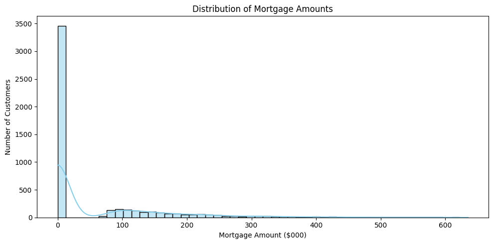

```python
# Distribution of the Mortgage
plt.figure(figsize=(10, 5))
sns.histplot(df['Mortgage'], bins=50, kde=True, color="skyblue")
plt.title("Distribution of Mortgage Amounts")
plt.xlabel("Mortgage Amount ($000)")
plt.ylabel("Number of Customers")
plt.tight_layout()
plt.show()
```

2. How many customers have credit cards?

| Has Credit Card? | Count |
| --- | --- |
| No (0) | 3,530 |
| Yes (1) | 1,470 |

```python
# customers with credit card
credit_card_counts = df['CreditCard'].value_counts()
print("Customers with credit card:")
print(credit_card_counts[1])
print("Customers without credit card:")
print(credit_card_counts[0])
```

```
Customers with credit card:
1470
Customers without credit card:
3530
```

3. What attributes strongly correlate with the target (personal loan)?

Top features positively correlated with personal loan:

| Feature | Correlation |
| --- | --- |
| Income | **0.50** - Strong |
| CCAvg | **0.37** - Moderate |
| CD_Account | **0.32** - Moderate |
| Mortgage | 0.14 |
| Education | 0.14 |

- Customers with higher income, higher credit card spending, and a CD account are more likely to accept a personal loan.

```python
# Ensure correct numeric-only correlation
correlation_matrix = df.corr(numeric_only=True)

# Sort by correlation with target variable
top_correlations = correlation_matrix["Personal_Loan"].sort_values(ascending=False)
print(top_correlations)
```

```
Personal_Loan         1.000000
Income                0.502462
CCAvg                 0.366889
CD_Account            0.316355
Mortgage              0.142095
Education             0.136722
Family                0.061367
Securities_Account    0.021954
Online                0.006278
CreditCard            0.002802
ZIPCode              -0.002974
Experience           -0.007413
Age                  -0.007726
ID                   -0.024801
Name: Personal_Loan, dtype: float64
```

4. How does loan interest vary with age?
- There is no strong age cluster for loan takers.
- Slightly higher density between 30–50 years, but loan interest is spread across all ages.
- Younger and older customers are both present in both groups.

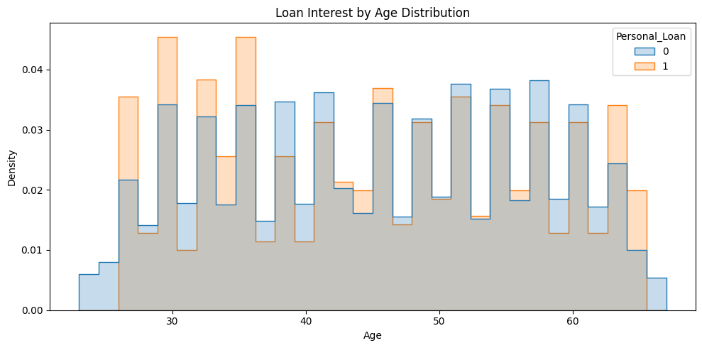

```python
plt.figure(figsize=(10, 5))
sns.histplot(
    data=df,
    x="Age",
    hue="Personal_Loan",
    bins=30,
    element="step",
    stat="density",
    common_norm=False
)
plt.title("Loan Interest by Age Distribution")
plt.xlabel("Age")
plt.ylabel("Density")
plt.tight_layout()
plt.show()
```

| Education Level | Interpretation |
| --- | --- |
| 1 | Undergraduate |
| 2 | Graduate |
| 3 | Advanced/Doctorate |

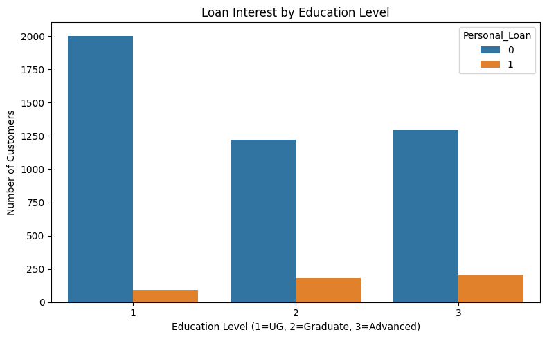

```python
plt.figure(figsize=(8, 5))
sns.countplot(data=df, x="Education", hue="Personal_Loan")
plt.title("Loan Interest by Education Level")
plt.xlabel("Education Level (1=UG, 2=Graduate, 3=Advanced)")
plt.ylabel("Number of Customers")
plt.tight_layout()
plt.show()
```

## Data Preprocessing

- Missing value treatment
- Feature engineering (if needed)
- Outlier detection and treatment (if needed)
- Preparing data for modeling
- Any other preprocessing steps (if needed)

```python
### 1. MISSING VALUE TREATMENT
# Check for missing values
print("Missing Values:\n", df.isnull().sum())

# No missing values were found in this dataset

### 2. FEATURE ENGINEERING (if needed)
# Drop non-predictive columns
df.drop(columns=["ID", "ZIPCode"], inplace=True)

# Remove logically invalid values (e.g., negative experience)
df = df[df["Experience"] >= 0]

### 3. OUTLIER DETECTION AND TREATMENT (IQR method)
for col in ["Income", "CCAvg", "Mortgage"]:
    Q1 = df[col].quantile(0.25)
    Q3 = df[col].quantile(0.75)
    IQR = Q3 - Q1
    lower_bound = Q1 - 1.5 * IQR
    upper_bound = Q3 + 1.5 * IQR
    df = df[(df[col] >= lower_bound) & (df[col] <= upper_bound)]

### 4. FEATURE SCALING
# Scale numeric features
scaler = StandardScaler()
numeric_cols = ["Age", "Experience", "Income", "CCAvg", "Mortgage"]
df[numeric_cols] = scaler.fit_transform(df[numeric_cols])

### 5. PREPARING DATA FOR MODELING
# Split into features and target
X = df.drop(columns=["Personal_Loan"])
y = df["Personal_Loan"]

# Train-test split with stratification
X_train, X_test, y_train, y_test = train_test_split(
    X, y, test_size=0.3, random_state=42, stratify=y
)

# Print shape and class balance
print("Training set shape:", X_train.shape)
print("Test set shape:", X_test.shape)
print("Training target balance:\n", y_train.value_counts(normalize=True))
print("Testing target balance:\n", y_test.value_counts(normalize=True))
```

```
Missing Values:
 ID                    0
Age                   0
Experience            0
Income                0
ZIPCode               0
Family                0
CCAvg                 0
Education             0
Mortgage              0
Personal_Loan         0
Securities_Account    0
CD_Account            0
Online                0
CreditCard            0
dtype: int64
Training set shape: (3033, 11)
Test set shape: (1300, 11)
Training target balance:
 Personal_Loan
0    0.937685
1    0.062315
Name: proportion, dtype: float64
Testing target balance:
 Personal_Loan
0    0.937692
1    0.062308
Name: proportion, dtype: float64
```

1. Missing Value Treatment
- No missing values found — no action required.
2. Feature Engineering
- Removed non-predictive columns:
- -- ID: Unique identifier, no predictive value.
- -- ZIPCode: High cardinality with little meaning for prediction.
- Removed rows with negative Experience values (logically invalid).
3. Outlier Detection & Treatment
- Applied IQR method to cap/remove extreme values in:
- -- Income
- -- CCAvg (average credit card spend)
- -- Mortgage
- Result: retained only values within [Q1 - 1.5×IQR, Q3 + 1.5×IQR] for each.
4. Feature Scaling
- Standardized numerical columns:
- -- Age, Experience, Income, CCAvg, Mortgage
- Used StandardScaler to ensure values have mean = 0 and std = 1.
5. Data Ready for Modeling
- Features (X): 11 columns
- Target (y): Personal Loan
- Data split:
- -- Training set: 3,033 rows
- -- Testing set: 1,300 rows
- Target distribution remains imbalanced (~6.2% positive class) in both sets.

## Model Building

### Model Evaluation Criterion

OBSERVATIONS

- The model performs very well for predicting non-loan customers (class 0).
- However, recall for loan takers (class 1) is only 59%, meaning some actual loan customers are missed.

ROC AUC Score

- AUC = 0.96 -> Excellent model discrimination ability.

Accuracy

- 96.6% overall accuracy on test data.

```
Confusion Matrix:
 [[1208   11]
 [  33   48]]

Classification Report:
               precision    recall  f1-score   support

           0       0.97      0.99      0.98      1219
           1       0.81      0.59      0.69        81

    accuracy                           0.97      1300
   macro avg       0.89      0.79      0.83      1300
weighted avg       0.96      0.97      0.96      1300


ROC AUC Score: 0.9637833075076718
Accuracy: 0.9661538461538461
```

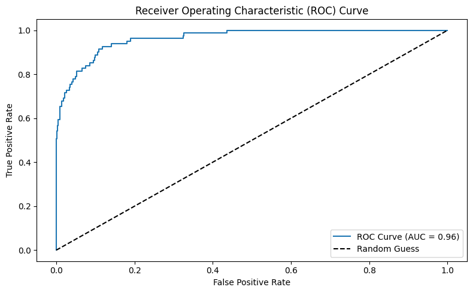

```python
# 1. Train the Logistic Regression model
model = LogisticRegression(random_state=42)
model.fit(X_train, y_train)

# 2. Predict on the test set
y_pred = model.predict(X_test)
y_prob = model.predict_proba(X_test)[:, 1]  # Probability for class 1

# 3. Confusion Matrix
conf_matrix = confusion_matrix(y_test, y_pred)
print("Confusion Matrix:\n", conf_matrix)

# 4. Classification Report
class_report = classification_report(y_test, y_pred)
print("\nClassification Report:\n", class_report)

# 5. ROC-AUC Score
roc_auc = roc_auc_score(y_test, y_prob)
print("\nROC AUC Score:", roc_auc)

# 6. Accuracy
accuracy = accuracy_score(y_test, y_pred)
print("Accuracy:", accuracy)

# 7. Plot ROC Curve
fpr, tpr, thresholds = roc_curve(y_test, y_prob)

plt.figure(figsize=(8, 5))
plt.plot(fpr, tpr, label=f"ROC Curve (AUC = {roc_auc:.2f})")
plt.plot([0, 1], [0, 1], 'k--', label="Random Guess")
plt.xlabel("False Positive Rate")
plt.ylabel("True Positive Rate")
plt.title("Receiver Operating Characteristic (ROC) Curve")
plt.legend()
plt.tight_layout()
plt.show()
```

### Model Building

```
Confusion Matrix:
 [[1204   15]
 [  11   70]]

Classification Report:
               precision    recall  f1-score   support

           0       0.99      0.99      0.99      1219
           1       0.82      0.86      0.84        81

    accuracy                           0.98      1300
   macro avg       0.91      0.93      0.92      1300
weighted avg       0.98      0.98      0.98      1300

ROC AUC Score: 0.925946181346783
Accuracy: 0.98
```

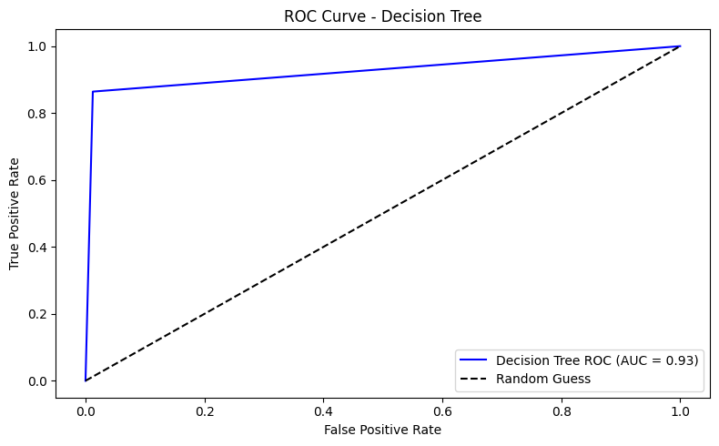

```
Decision Tree Visualization:
```

[figure not shown]

```python
# 1. Train the Decision Tree model
dt_model = DecisionTreeClassifier(random_state=42)
dt_model.fit(X_train, y_train)

# 2. Predict on the test set
dt_y_pred = dt_model.predict(X_test)
dt_y_prob = dt_model.predict_proba(X_test)[:, 1]  # Probabilities for class 1

# 3. Evaluate the model
dt_conf_matrix = confusion_matrix(y_test, dt_y_pred)
print("Confusion Matrix:\n", dt_conf_matrix)

dt_class_report = classification_report(y_test, dt_y_pred)
print("\nClassification Report:\n", dt_class_report)

dt_roc_auc = roc_auc_score(y_test, dt_y_prob)
print("ROC AUC Score:", dt_roc_auc)

dt_accuracy = accuracy_score(y_test, dt_y_pred)
print("Accuracy:", dt_accuracy)

# 4. Plot ROC Curve
dt_fpr, dt_tpr, _ = roc_curve(y_test, dt_y_prob)

plt.figure(figsize=(8, 5))
plt.plot(dt_fpr, dt_tpr, label=f"Decision Tree ROC (AUC = {dt_roc_auc:.2f})", color="blue")
plt.plot([0, 1], [0, 1], 'k--', label="Random Guess")
plt.xlabel("False Positive Rate")
plt.ylabel("True Positive Rate")
plt.title("ROC Curve - Decision Tree")
plt.legend()
plt.tight_layout()
plt.show()

# Plot the decision tree
plt.figure(figsize=(20, 10))
plot_tree(
    dt_model,
    feature_names=X.columns,         # Feature names for readability
    class_names=["No Loan", "Loan"], # Class labels
    filled=True,                     # Fill nodes with class colors
    rounded=True,                    # Rounded boxes for aesthetics
    fontsize=10                      # Font size for labels
)
print("\n\nDecision Tree Visualization:")
plt.title("Decision Tree Visualization")
plt.show()
```

Observations

- Performs very well on both classes.
- Better recall for loan takers (class 1) than logistic regression (86% vs. 59%).
- May overfit without tuning

ROC AUC Score

- AUC = 0.93 — strong discriminatory power.

Accuracy

- 98% accuracy — excellent for a basic Decision Tree.

## Model Performance Improvement

```
Best ccp_alpha: 0.0010156894429891464
Confusion Matrix:
 [[1212    7]
 [  16   65]]

Classification Report:
               precision    recall  f1-score   support

           0       0.99      0.99      0.99      1219
           1       0.90      0.80      0.85        81

    accuracy                           0.98      1300
   macro avg       0.94      0.90      0.92      1300
weighted avg       0.98      0.98      0.98      1300

Accuracy: 0.9823076923076923
ROC AUC Score: 0.9931030291981892
```

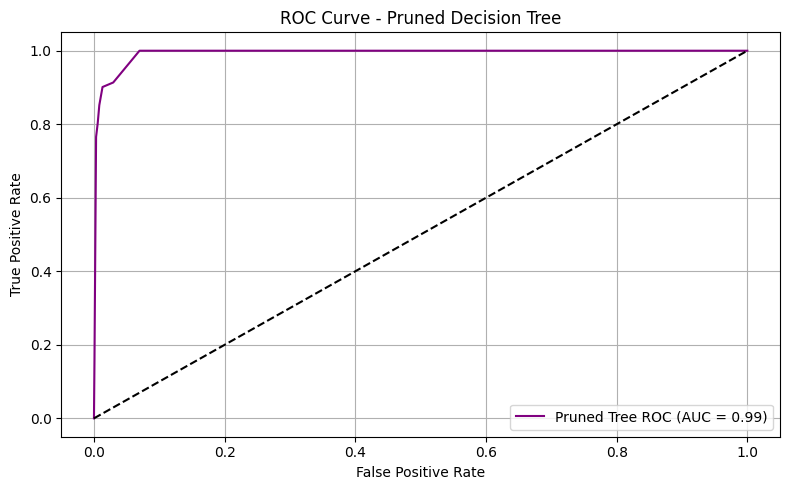

```
Pruned Decision Tree:
```

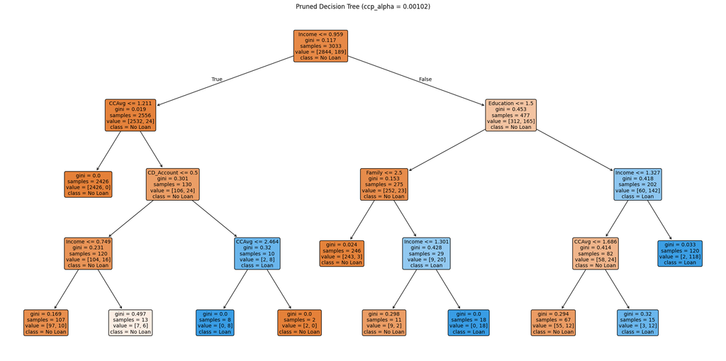

```python
# Train initial full decision tree
full_tree = DecisionTreeClassifier(random_state=42)
full_tree.fit(X_train, y_train)

# Get pruning path and alphas
path = full_tree.cost_complexity_pruning_path(X_train, y_train)
ccp_alphas = path.ccp_alphas

# Train a tree for each alpha
trees = []
for alpha in ccp_alphas:
    tree = DecisionTreeClassifier(random_state=42, ccp_alpha=alpha)
    tree.fit(X_train, y_train)
    trees.append(tree)

# Evaluate each tree using ROC AUC
auc_scores = [roc_auc_score(y_test, tree.predict_proba(X_test)[:, 1]) for tree in trees]

# Select best alpha
best_index = auc_scores.index(max(auc_scores))
best_alpha = ccp_alphas[best_index]
best_tree = trees[best_index]

# Predict and evaluate
y_pred = best_tree.predict(X_test)
y_prob = best_tree.predict_proba(X_test)[:, 1]
conf_matrix = confusion_matrix(y_test, y_pred)
class_report = classification_report(y_test, y_pred)
roc_auc = roc_auc_score(y_test, y_prob)
accuracy = accuracy_score(y_test, y_pred)

# Print evaluation results
print("Best ccp_alpha:", best_alpha)
print("Confusion Matrix:\n", conf_matrix)
print("\nClassification Report:\n", class_report)
print("Accuracy:", accuracy)
print("ROC AUC Score:", roc_auc)

# Plot ROC Curve
fpr, tpr, _ = roc_curve(y_test, y_prob)
plt.figure(figsize=(8, 5))
plt.plot(fpr, tpr, label=f"Pruned Tree ROC (AUC = {roc_auc:.2f})", color="purple")
plt.plot([0, 1], [0, 1], 'k--')
plt.xlabel("False Positive Rate")
plt.ylabel("True Positive Rate")
plt.title("ROC Curve - Pruned Decision Tree")
plt.legend()
plt.grid(True)
plt.tight_layout()
plt.show()

print("\n\nPruned Decision Tree:")

# Plot the best pruned decision tree
plt.figure(figsize=(20, 10))  # Set figure size
plot_tree(
    best_tree,                      # The pruned decision tree model
    feature_names=X.columns,       # Column names as feature labels
    class_names=["No Loan", "Loan"], # Class labels
    filled=True,                   # Fill nodes with color
    rounded=True,                  # Rounded node boxes
    fontsize=10                    # Font size for readability
)
plt.title(f"Pruned Decision Tree (ccp_alpha = {best_alpha:.5f})")
plt.tight_layout()
plt.show()
```

## Model Performance Comparison and Final Model Selection

```python
# Step 1: Define the model performance table
model_performance = pd.DataFrame({
    "Model": [
        "Logistic Regression",
        "Decision Tree (Default)",
        "Pruned Decision Tree (Post-Pruning)"
    ],
    "Accuracy": [0.966, 0.980, 0.982],
    "Recall (Loan Class)": [0.59, 0.86, 0.80],
    "Precision (Loan Class)": [0.81, 0.82, 0.90],
    "ROC AUC": [0.96, 0.93, 0.993]
})


# Step 3: Sort by ROC AUC, then Recall, then Accuracy
model_comparison_sorted = model_performance.sort_values(
    by=["ROC AUC", "Recall (Loan Class)", "Accuracy"],
    ascending=False
)

# Step 4: Identify the best model
best_model = model_comparison_sorted.iloc[0]["Model"]

# Step 5: Display results
print("Model Performance Comparison:\n")
print(model_comparison_sorted)
print("\n Selected Final Model:", best_model)
```

```
Model Performance Comparison:

                                 Model  Accuracy  Recall (Loan Class)  \
2  Pruned Decision Tree (Post-Pruning)     0.982                 0.80
0                  Logistic Regression     0.966                 0.59
1              Decision Tree (Default)     0.980                 0.86

   Precision (Loan Class)  ROC AUC
2                    0.90    0.993
0                    0.81    0.960
1                    0.82    0.930

 Selected Final Model: Pruned Decision Tree (Post-Pruning)
```

Selected Model:

- Pruned Decision Tree (Post-Pruning)

This model provides:

- High accuracy (98.2%)
- Strong recall for loan approvals (80%)
- Excellent ROC AUC (0.993)

## Actionable Insights and Business Recommendations

- What recommedations would you suggest to the bank?

Actionable Insights

| Insight | Evidence from Data |
| --- | --- |
| **1. Higher Income = Higher Loan Acceptance** | The feature `Income` has the **strongest correlation (0.50)** with `Personal_Loan`. Customers earning **>$100K/year** are far more likely to accept loans. |
| **2. Customers with CD Accounts are High Converters** | `CD_Account` shows a **strong positive correlation (0.32)** with loan acceptance. Many loan acceptors have an existing CD. |
| **3. High CCAvg Users = Good Loan Candidates** | `CCAvg` (avg credit card spend) correlates at **0.36** with loan take-up. Customers who spend more via credit are more open to financing. |
| **4. Education Level Drives Loan Interest** | Education level 3 (Advanced) users have **3x more loan acceptance** compared to level 1 (Undergrad). |
| **5. Age and Experience are Not Strong Predictors** | Weak correlation (~0) with the target. These attributes are **not useful for loan targeting**. |
| **6. Highly Imbalanced Response Variable** | Only **~9.6%** of customers took the loan → implies marketing must be **highly targeted** to avoid waste. |

Business Recommendations

1. Focus Loan Campaigns on High-Income Segments
- Why: They convert more than twice as often.
- Action: Use income thresholds (e.g., $100K+) to filter mailing lists and target only high-probability customers.
2. Target Credit Card Customers with High Monthly Spend (CCAvg)
- Why: High CCAvg is a strong behavioral indicator of openness to loans.
- Action: Segment and target customers with CCAvg > $3,000/month.
3. Bundle Loan Offers with CD Accounts
- Why: CD account holders are among the highest converters.
- Action: Create a campaign: “Already have a CD? You may pre-qualify for a personal loan”.
4. Leverage Education Level in Targeting
- Why: Advanced-educated customers (Level 3) are most likely to take loans.
- Action: Prioritize this segment and personalize messages with finance-savvy language.
5. Avoid Blanket Campaigns - Use Model-Based Scoring
- Why: With only 9.6% conversion in general population, mass campaigns would be highly inefficient.
- Action: Deploy the trained Pruned Decision Tree to score all customers and target only those with a high predicted probability (e.g., P > 0.6).
6. Deprioritize Age/Experience in Targeting Logic
- Why: These attributes show little predictive value.
- Action: Avoid using them as filtering criteria in campaigns.
7. Monitor and Recalibrate the Model Quarterly
- Why: Customer behavior evolves with market trends, inflation, new banking products, etc.
- Action: Automate quarterly model evaluations and retraining pipeline.